# Practical Part of Homework 2

## Koosha Jaferian - 95105454

## Question 1

First of all we generate 1000 samples of exponential distribution and draw it’s histogram and probability density funtion. they will look like this :

## Histogram

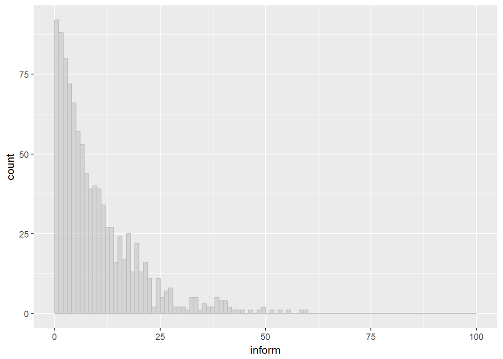

## Density

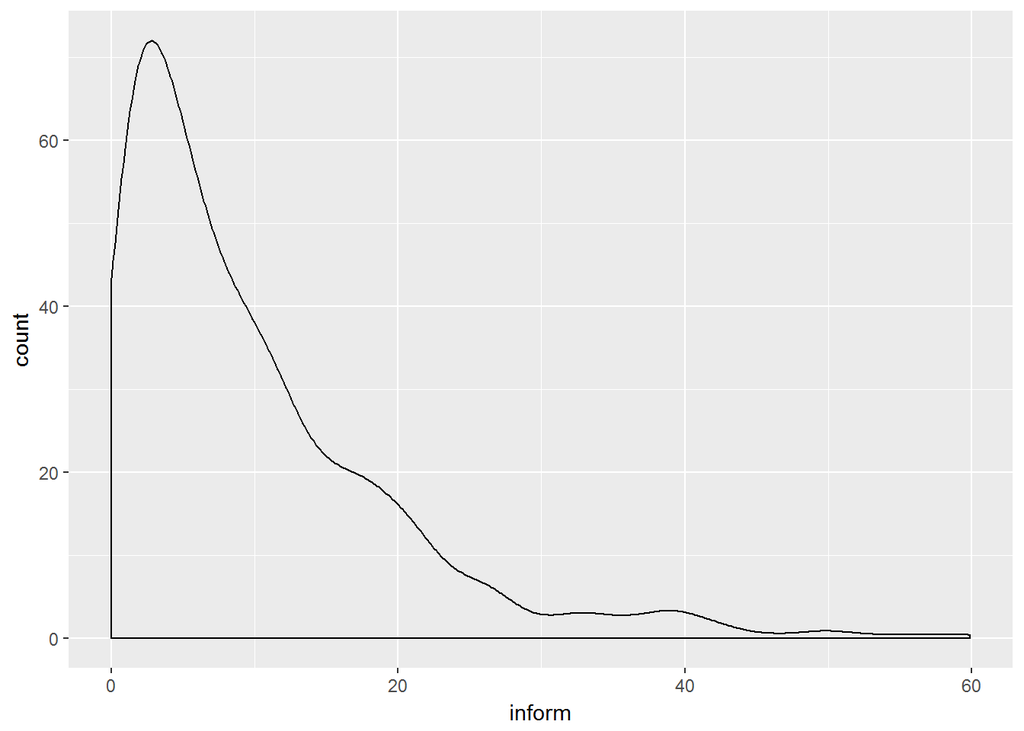

Now we omit the samples with the value less than 10. then we will draw the Histogram and Probability density again. they will look like this :

## Histogram

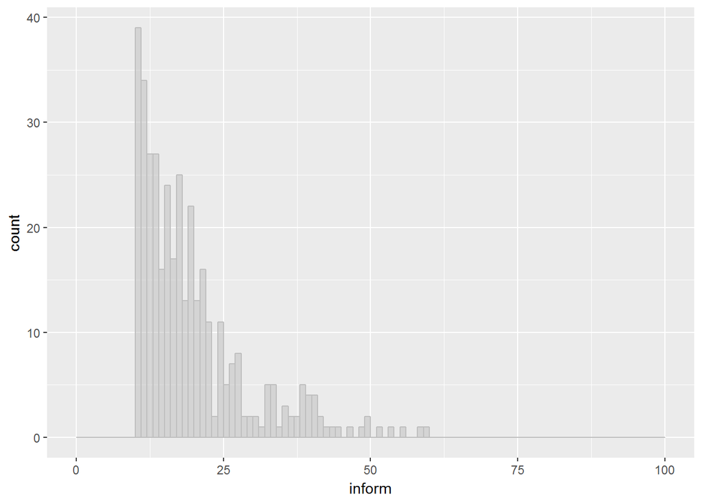

## Density

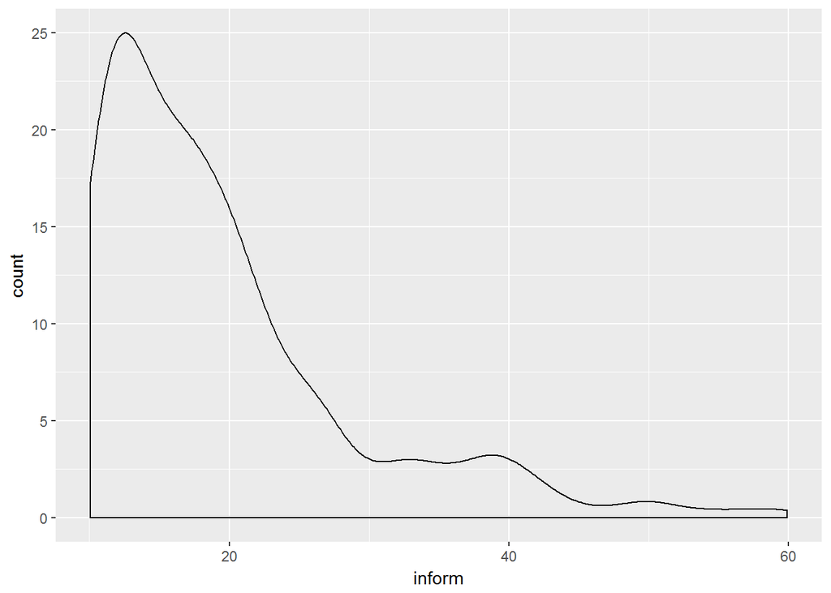

we can easily see that the density function shape is almost the same, the result will show the Memorylessness of the exponential Distribution!

## Question 2

now we generate 1000 samples of geometric distribution with p = 0.01.

Then we divide the samples by 10 and draw their histogram!

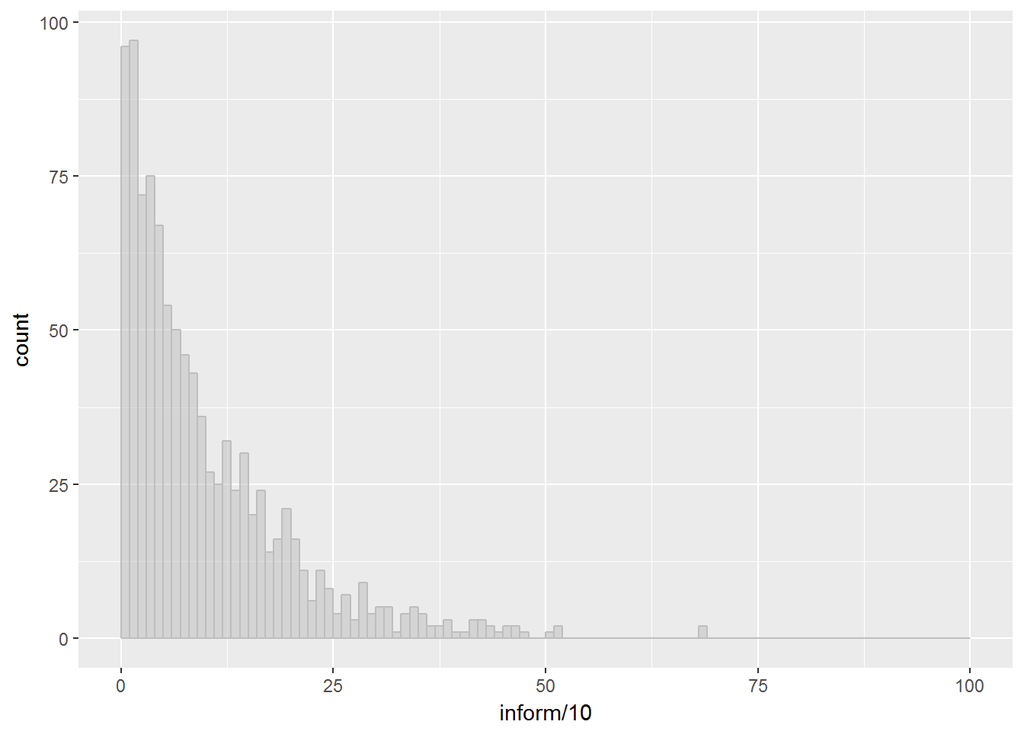

you can easily see that this shape is very similar to the previous one. the result shows that if p is so small and n is large, the Geometric distribution and Exponentioal Distribution are really close to each other.

## Question 3

Now we are going to simulate 1000 days of the secretary and count the number of calls in each day (8 hours)

After generating the data we will draw the histogram of “number of calls”. it looks like this :

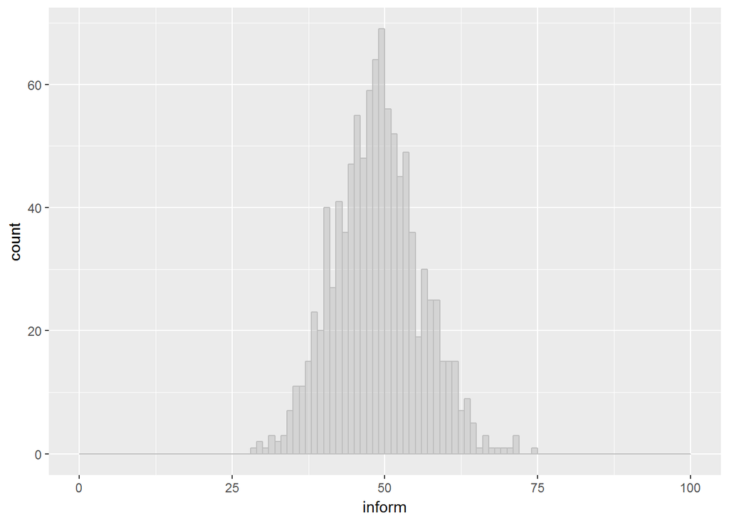

the shape of the histogram is similar to Poisson Distribution!